# MOGPTK Kernels

This notebook explores the parameterisation of multi-output Gaussian process kernels in the spectral (Fourier) and time domains.

For full details see:

> Parra, Gabriel, and Felipe Tobar. 2017. “Spectral Mixture Kernels for Multi-Output Gaussian Processes.” arXiv:1709.01298. Preprint, arXiv, November 3. https://doi.org/10.48550/arXiv.1709.01298.

```r
library(ggplot2)
library(latex2exp)
library(patchwork)
library(gsignal)
library(latex2exp)

theme_set(theme_minimal())
```

# Multi-output (Single) Spectral Mixture ($Q = 1$)

In the spectral domain, specify the spectral density $S_{ij}(\omega)$ as a squared-exponential (SE) function.

$$S_{ij}(\omega) = \frac{w_{ij}}{2}\left\{\exp\left[ -\frac{1}{2}(\omega - \mu_{ij})^\top \Sigma_{ij}^{-1}(\omega - \mu_{ij} ) + \imath(\theta_{ij}^\top \omega + \phi_{ij})\right] + \exp\left[ -\frac{1}{2}(\omega + \mu_{ij})^\top \Sigma_{ij}^{-1}(\omega + \mu_{ij} ) + \imath(-\theta_{ij}^\top \omega + \phi_{ij})\right]\right\}$$

- Magnitude (weight of component): $w_{ij}$
- Covariance: $\Sigma_{ij}$
- Mean: $\mu_{ij}$
- Delay: $\theta_{ij} = \theta_i - \theta_j$
- Phase: $\phi_{ij} = \phi_i - \phi_j$

**NB:** the above parameters describe the shape of the kernel in the *spectral* domain.

```r
# Function that returns the cross-spectral density
S_ij <- function(omegas, i, j, ws, Sigmas, mus, thetas, phis) {

  Sigma_ij <- 2 * Sigmas[i] / (Sigmas[i] + Sigmas[j]) * Sigmas[j]
  mu_ij <- (Sigmas[i]*mus[j] + Sigmas[j]*mus[i]) / (Sigmas[i] + Sigmas[j])
  w_ij <- ws[i]*ws[j] * exp( -0.25*(mus[i]-mus[j])^2 / (Sigmas[i] + Sigmas[j]) )
  theta_ij <- thetas[i] - thetas[j]
  phi_ij <- phis[i] - phis[j]

  w_ij/2 * (
    exp(
      complex(
        real = -0.5 * (omegas - mu_ij)^2 / Sigma_ij,
        imaginary = theta_ij * omegas + phi_ij
      )
    ) +
      exp(
      complex(
        real = -0.5 * (omegas + mu_ij)^2 / Sigma_ij,
        imaginary = -theta_ij * omegas + phi_ij
      )
    )
  )
}
```

The Fourier pair of the above is

$$k_{ij}(\tau) = \alpha_{ij} \exp \left( -\frac{1}{2} (\tau + \theta_{ij})^\top \Sigma_{ij}(\tau + \theta_{ij}) \right) \cos \left( (\tau + \theta_{ij})^\top \mu_{ij} + \phi_{ij} \right), \qquad \alpha_{ij} = w_{ij} (2\pi)^{n/2} | \Sigma_{ij} |^{1/2}$$

```r
# Multi-output spectral kernel
k_ij <- function(taus, i, j, ws, sigmas, mus, thetas, phis) {

  Sigma_ij <- 2 * Sigmas[i] / (Sigmas[i] + Sigmas[j]) * Sigmas[j]
  mu_ij <- (Sigmas[i]*mus[j] + Sigmas[j]*mus[i]) / (Sigmas[i] + Sigmas[j])
  w_ij <- ws[i]*ws[j] * exp( -0.25*(mus[i]-mus[j])^2 / (Sigmas[i] + Sigmas[j]) )
  theta_ij <- thetas[i] - thetas[j]
  phi_ij <- phis[i] - phis[j]

  alpha_ij <- w_ij * (2*pi)^0.5 * abs(Sigma_ij)^0.5
  alpha_ij*exp(-0.5*(taus+theta_ij)^2*Sigma_ij) * cos( (taus+theta_ij)*mu_ij + phi_ij)
}
```

```r
plot_ktau_Somega <- function(taus, ws, Sigmas, mus, thetas, phis) {

  tau_inc <- taus[2] - taus[1]

  ks <- k_ij(taus, 1, 2, ws, Sigmas, mus, thetas, phis)

  #omegas <- seq_along(taus)*(1/tau_inc)/length(taus)
  omegas <- ( seq_along(taus)-(length(taus)/2) ) * (1/(tau_inc * length(taus)))

  Ss <- S_ij(omegas, 1, 2, ws, Sigmas, mus, thetas, phis)

  p1 <- ggplot() +
    aes(x = taus) +
    geom_vline(xintercept = 0, linetype = "dashed", alpha = 0.5) +
    geom_line(aes(y = Re(ks), colour = "Re")) +
    geom_line(aes(y = Im(ks), colour = "Im")) +
    labs(title = "Covariance",
         x = TeX("$\\tau$"), y = TeX("$k(\\tau)$"), colour = "") +
    scale_colour_manual(values = c("Re" = "purple", "Im" = "orange"))

  p2 <- ggplot() +
    aes(x = omegas) +
    geom_vline(xintercept = 0, linetype = "dashed", alpha = 0.5) +
    geom_line(aes(y = Re(Ss), colour = "Re")) +
    geom_line(aes(y = Im(Ss), colour = "Im")) +
    labs(title = "Spectral Density",
         x = TeX("$\\omega$"), y = TeX("$S(\\omega)$"), colour = "") +
    scale_colour_manual(values = c("Re" = "blue", "Im" = "red"))

  p1 + p2
}
```

## $\theta_{ij} = 0$, $\phi_{ij} = 0$

- PSD is symmetrical, positive real-valued
- Kernel is real-valued, symmetrical, centred on zero

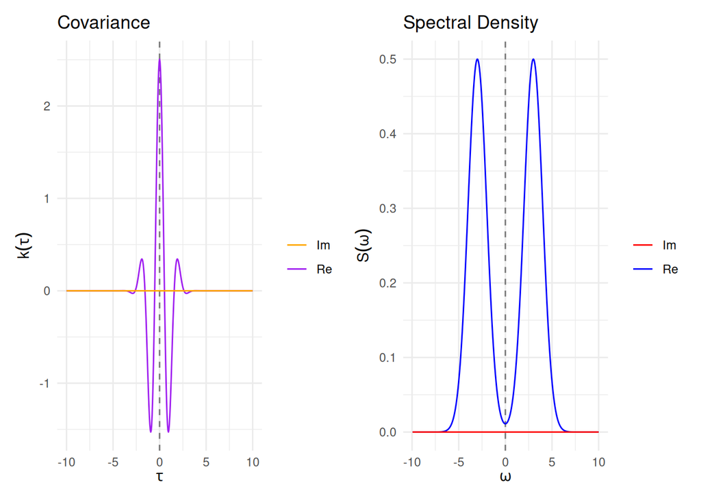

```r
ws <- c(1,1)
mus <- c(3,3)
Sigmas <- c(1.0, 1.0)

thetas <- c(0, 0)
phis <- c(0, 0)

tau_inc <- 1/20
taus <- seq(from = -10, to = 10, by = tau_inc)

plot_ktau_Somega(taus, ws, Sigmas, mus, thetas, phis)
```

### Numerical inverse-FFT

$$k_{ij}(\tau) = \mathcal{F}^{-1}\{S_{ij}(\omega)\}(\tau)$$

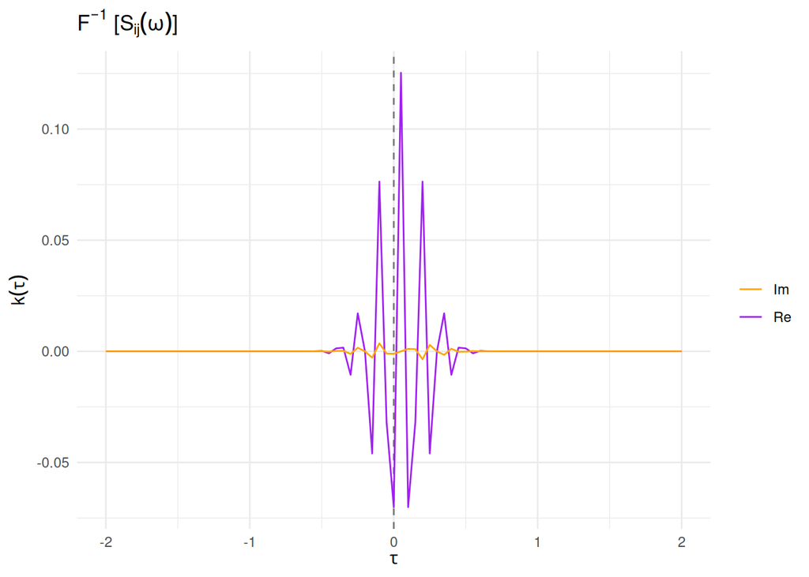

```r
omegas <- ( seq_along(taus)-(length(taus)/2) ) * (1/(tau_inc * length(taus)))
Ss <- S_ij(omegas, 1, 2, ws, Sigmas, mus, thetas, phis)

Ss_ifft <- ifftshift( fft(Ss, inverse = TRUE)/length(Ss) )

ggplot() +
  aes(x = taus) +
  geom_vline(xintercept = 0, linetype = "dashed", alpha = 0.5) +
  geom_line(aes(y = Re(Ss_ifft), colour = "Re")) +
  geom_line(aes(y = Im(Ss_ifft), colour = "Im")) +
  labs(title = TeX("$F^{-1}\\, [ S_{ij}(\\omega) ] $"),
       x = TeX("$\\tau$"), y = TeX("$k(\\tau)$"), colour = "") +
  scale_colour_manual(values = c("Re" = "purple", "Im" = "orange")) +
  xlim(c(-2,2))
```

$$S_{ij}(\omega) = \mathcal{F}\{k_{ij}(\tau)\}$$

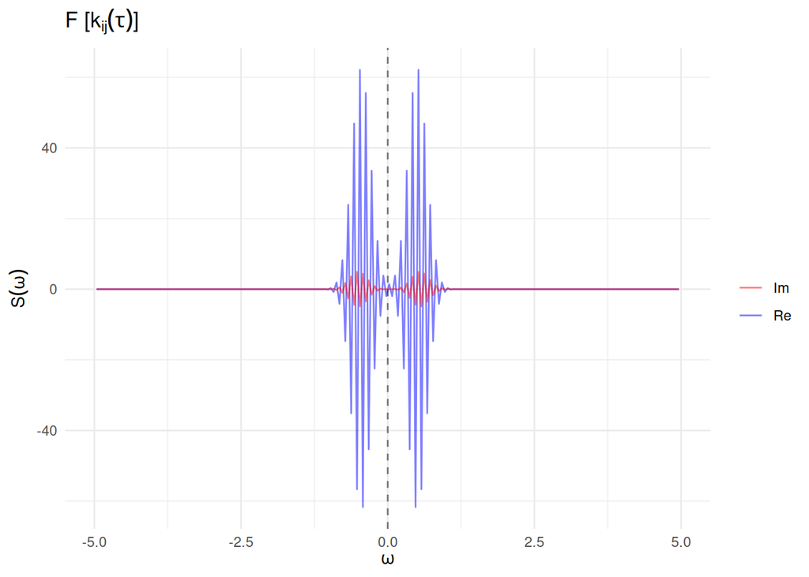

```r
ks <- k_ij(taus, 1, 2, ws, Sigmas, mus, thetas, phis)
ks_fft <- fftshift( fft(ks) )

ggplot() +
    aes(x = omegas) +
    geom_vline(xintercept = 0, linetype = "dashed", alpha = 0.5) +
    geom_line(aes(y = Re(ks_fft), colour = "Re"), alpha = 0.5) +
    geom_line(aes(y = Im(ks_fft), colour = "Im"), alpha = 0.5) +
    labs(title = TeX("$F\\, [ k_{ij}(\\tau) ] $"),
         x = TeX("$\\omega$"), y = TeX("$S(\\omega)$"), colour = "") +
    scale_colour_manual(values = c("Re" = "blue", "Im" = "red")) +
  xlim(c(-5,5))
```

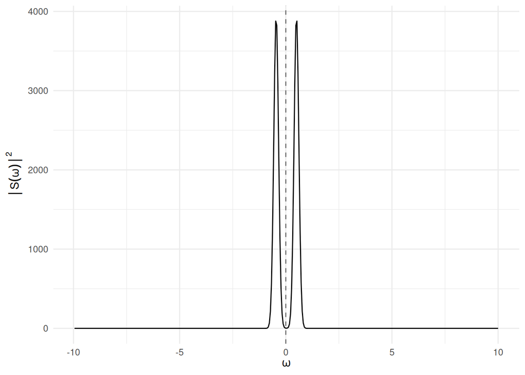

```r
ggplot() +
    aes(x = omegas) +
    geom_vline(xintercept = 0, linetype = "dashed", alpha = 0.5) +
    geom_line(aes(y = abs(ks_fft)^2)) +
    labs(x = TeX("$\\omega$"), y = TeX("$|S(\\omega)|^2$"))
```

## $\theta_{ij} = 0$, $\phi_{ij} != 0$

- PSD is symmetrical, positive-valued, complex-valued
- Kernel is non-symmetrical, real-valued, centred on zero

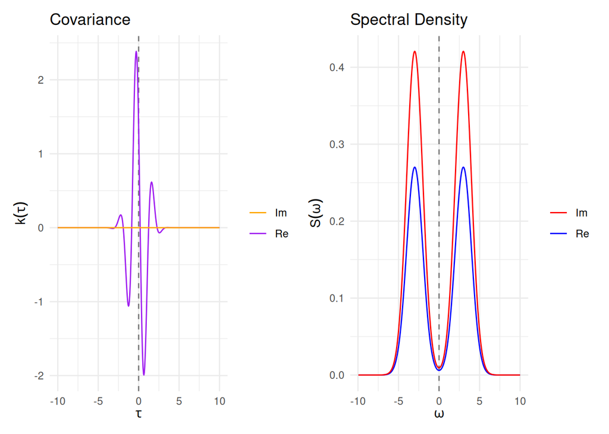

```r
thetas <- c(0, 0)
phis <- c(0, -1)

plot_ktau_Somega(taus, ws, Sigmas, mus, thetas, phis)
```

# $\theta_{ij} != 0$, $\phi_{ij} = 0$

- PSD is symmetrical, complex-valued
- Kernel is symmetrical, real-valued, not centred on zero

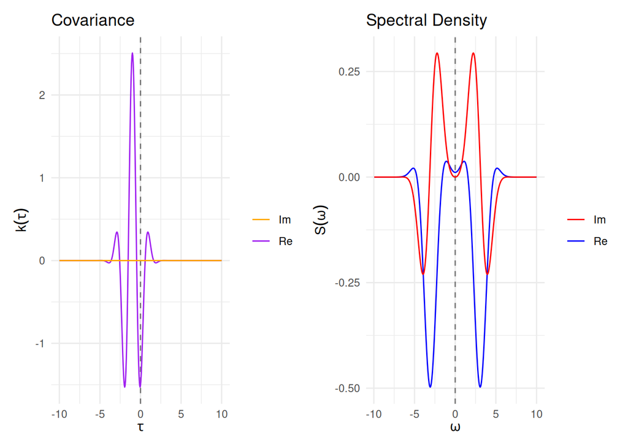

```r
thetas <- c(0, -1)
phis <- c(0, 0)

plot_ktau_Somega(taus, ws, Sigmas, mus, thetas, phis)
```